# Clustering

Katherine Li

11/13/2019

## *PART1:Collect the Data*

#### import data

```r
#install.packages(c("stats","mice","factoextra","tidyverse"))
library(readr)
CustomerScore <- read_csv("https://s3.amazonaws.com/notredame.analytics.data/mallcustomers.csv")
```

## *PART2:Explore and Prepare the Data*

#### 1. Using a predictive approach, impute the missing values.

#test if gender has missing values.

```r
library(dplyr)
library(mice)
CustomerScore1<- CustomerScore%>%
  mutate(Gender=as.factor(Gender))
summary(CustomerScore1)
```

```
##    CustomerID        Gender         Age           Income
##  Min.   :  1.00   Female:112   Min.   :18.00   Length:200
##  1st Qu.: 50.75   Male  : 88   1st Qu.:28.75   Class :character
##  Median :100.50                Median :36.00   Mode  :character
##  Mean   :100.50                Mean   :38.85
##  3rd Qu.:150.25                3rd Qu.:49.00
##  Max.   :200.00                Max.   :70.00
##  SpendingScore
##  Min.   : 1.00
##  1st Qu.:34.75
##  Median :50.00
##  Mean   :50.20
##  3rd Qu.:73.00
##  Max.   :99.00
```

#mice as a predictive approach, allowed us to impute the missing gender variable in this case. After imputation, we use summary to test if the missing variable is approperiately imputated.

```r
imputed_CustomerScore1 <- mice(CustomerScore1,m=1,maxit=5,meth='logreg',seed=1234)
```

```
##
##   1   1
##   2   1
##   3   1
##   4   1
##   5   1
```

```r
complete_CustomerScore1<- mice::complete(imputed_CustomerScore1)
summary(complete_CustomerScore1)
```

```
##    CustomerID        Gender         Age           Income
##  Min.   :  1.00   Female:112   Min.   :18.00   Length:200
##  1st Qu.: 50.75   Male  : 88   1st Qu.:28.75   Class :character
##  Median :100.50                Median :36.00   Mode  :character
##  Mean   :100.50                Mean   :38.85
##  3rd Qu.:150.25                3rd Qu.:49.00
##  Max.   :200.00                Max.   :70.00
##  SpendingScore
##  Min.   : 1.00
##  1st Qu.:34.75
##  Median :50.00
##  Mean   :50.20
##  3rd Qu.:73.00
##  Max.   :99.00
```

#### 2. Convert these values from strings to numbers.

#In order to convert a string with sign and coma into integer, we first changed them to pure number and then do the convertion.

```r
library(stringr)
complete_CustomerScore1<- complete_CustomerScore1%>%
  mutate(Income=str_replace_all(Income,"USD",""))%>%
  mutate(Income=str_replace_all(Income, ",",""))%>%
  mutate(Income=as.numeric(Income))
```

## *PART III: Segment Customers*

##### 1. Using the k-means clustering approach, segment the retail card customers into 3 clusters.

#We create a new data with only the income and spendingscore in it. #In order to avoid features with large ranges from dominating our model, #we normalize features in the new dataset using the z-score normalization.

```r
complete_CustomerScore2 <- complete_CustomerScore1%>%
  select(-CustomerID,-Gender,-Age)

complete_CustomerScore2<- scale(complete_CustomerScore2)
summary(complete_CustomerScore2)
```

```
##      Income         SpendingScore
##  Min.   :-1.73465   Min.   :-1.905240
##  1st Qu.:-0.72569   1st Qu.:-0.598292
##  Median : 0.03579   Median :-0.007745
##  Mean   : 0.00000   Mean   : 0.000000
##  3rd Qu.: 0.66401   3rd Qu.: 0.882916
##  Max.   : 2.91037   Max.   : 1.889750
```

```r
#install.packages("factoextra")
library(factoextra)
set.seed(1234)
k_3 <- kmeans(complete_CustomerScore2, centers=3, nstart = 25)
```

#### 2. Create a visualization of the 3 clusters.

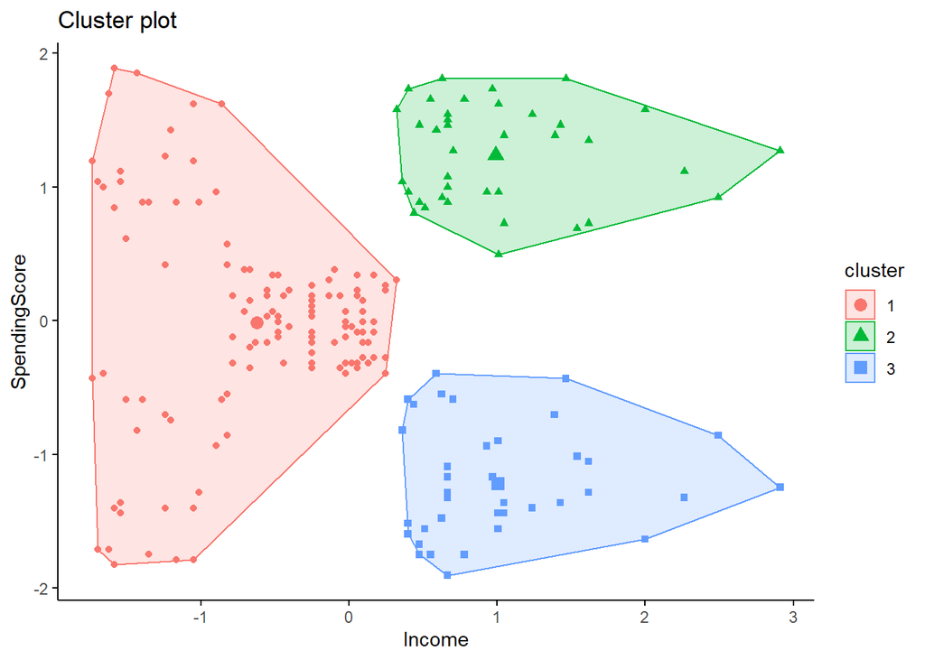

```r
fviz_cluster(k_3, data = complete_CustomerScore2,ggthem=theme_classic(),labelsize=0)
```